# Tugas Praktikum 6

DIANI RARAS PUSPITA

2025-10-09

```r
library(ggplot2)
library(tsibble)
library(tseries)
library(MASS)
set.seed(8990)
```

## Masukan Data

```r
data <- data.frame(
  waktu = 376:500,
  nilai = c(14367,14454,14506,14495,14666,
            14672,14521,14432,14609,14839,
            14817,14975,14977,14996,14974,
            14778,14945,14636,14837,14826,
            14867,14824,14994,15089,15303,
            15285,15462,15522,15549,15610,
            15474,15629,15675,15362,15582,
            15616,15566,15509,15602,15115,
            15056,14970,15079,15182,15159,
            15258,15255,15473,15369,15165,
            14969,14934,14783,14929,14666,
            14668,14843,14929,15008,14875,
            14886,14954,15043,15036,15158,
            14996,15041,15095,15139,15324,
            15314,15291,15194,15379,15360,
            15346,15487,15636,15696,15864,
            15904,15582,15683,15399,15447,
            15399,15560,15283,15409,15383,
            15478,15503,15601,15768,15727,
            15598,15629,15586,15692,15536,
            15639,15803,15873,15883,16112,
            16210,16232,15951,16047,15920,
            16038,16244,16268,16480,16470,
            16343,16239,16067,16208,16284,
            16135,15934,15672,15484,15649)
)

head(data)
```

```
##   waktu nilai
## 1   376 14367
## 2   377 14454
## 3   378 14506
## 4   379 14495
## 5   380 14666
## 6   381 14672
```

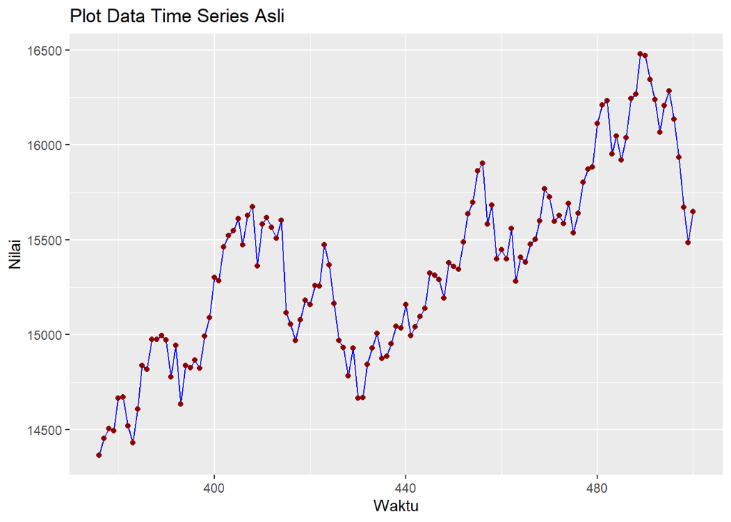

```r
ggplot(data, aes(x=waktu, y=nilai)) +
  geom_line(color="blue") +
  geom_point(color="darkred") +
  labs(title="Plot Data Time Series Asli",
       x="Waktu", y="Nilai")
```

## Cek Stasioneritas

### Plot ACF dan PACF

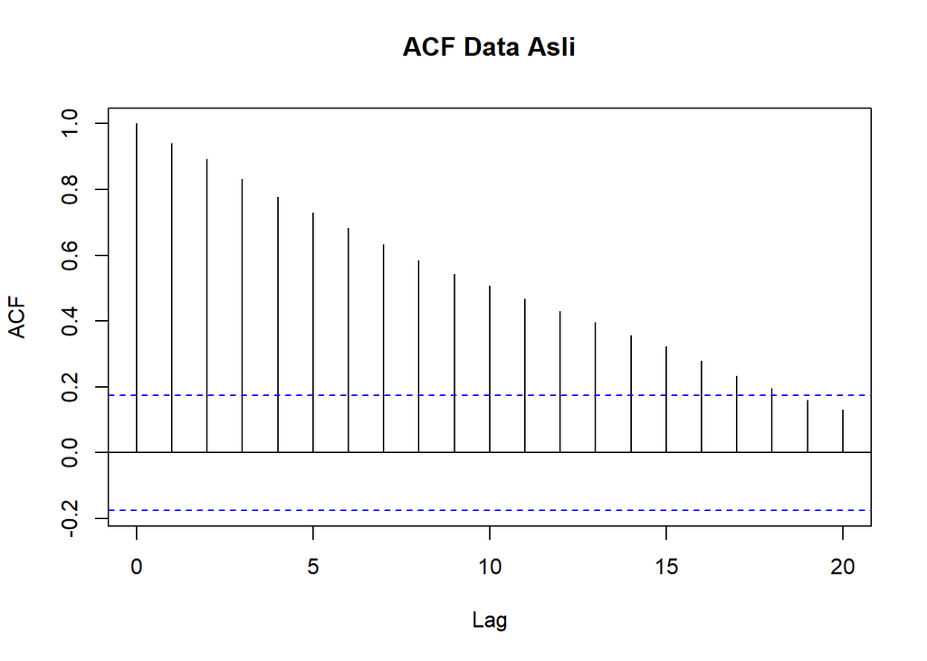

```r
acf(data$nilai, main="ACF Data Asli")
```

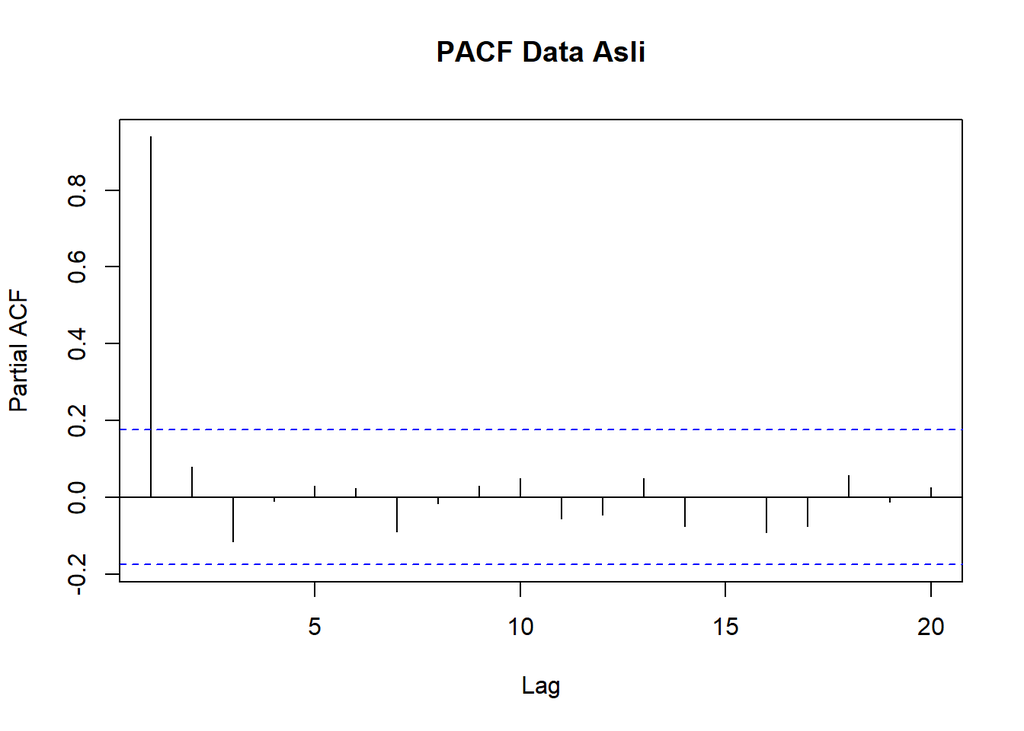

```r
pacf(data$nilai, main="PACF Data Asli")
```

Dari hasil plot ACF dan PACF pada data asli, terlihat bahwa nilai **ACF menurun secara perlahan (decay lambat)** dan tidak langsung putus pada lag awal. Hal ini mengindikasikan bahwa data memiliki tren dan **belum stasioner dalam rataan (mean)**.

PACF menunjukkan spike signifikan pada lag 1 dan menurun setelahnya. Pola seperti ini juga mendukung kesimpulan bahwa **data masih mengandung komponen non-stasioner**.

Dengan demikian, diperlukan proses **differencing** untuk membuat data menjadi stasioner sebelum dilakukan pemodelan lebih lanjut.

### Uji Augmented Dickey-Fuller (ADF)

```r
adf.test(data$nilai)
```

```
##
##  Augmented Dickey-Fuller Test
##
## data:  data$nilai
## Dickey-Fuller = -2.5062, Lag order = 4, p-value = 0.3662
## alternative hypothesis: stationary
```

Nilai p-value diperoleh 0.3662, maka p-value > 0.05 → *Data tidak stasioner.*

**Data asli** menunjukkan pola tren, ACF yang turun lambat, serta hasil uji ADF dengan p-value > 0.05. Hal ini mengindikasikan bahwa data **belum stasioner dalam rataan** meskipun ragam relatif stabil.

## Penanganan

### Differencing Orde 1

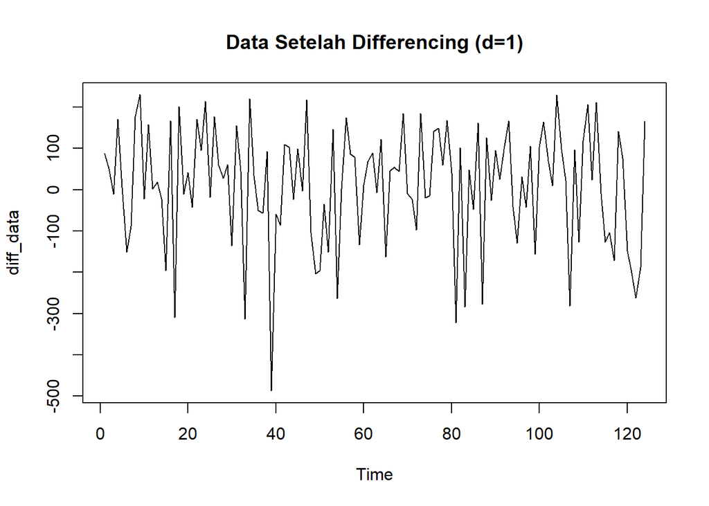

```r
diff_data <- diff(data$nilai, differences=1)

plot.ts(diff_data, main="Data Setelah Differencing (d=1)")
```

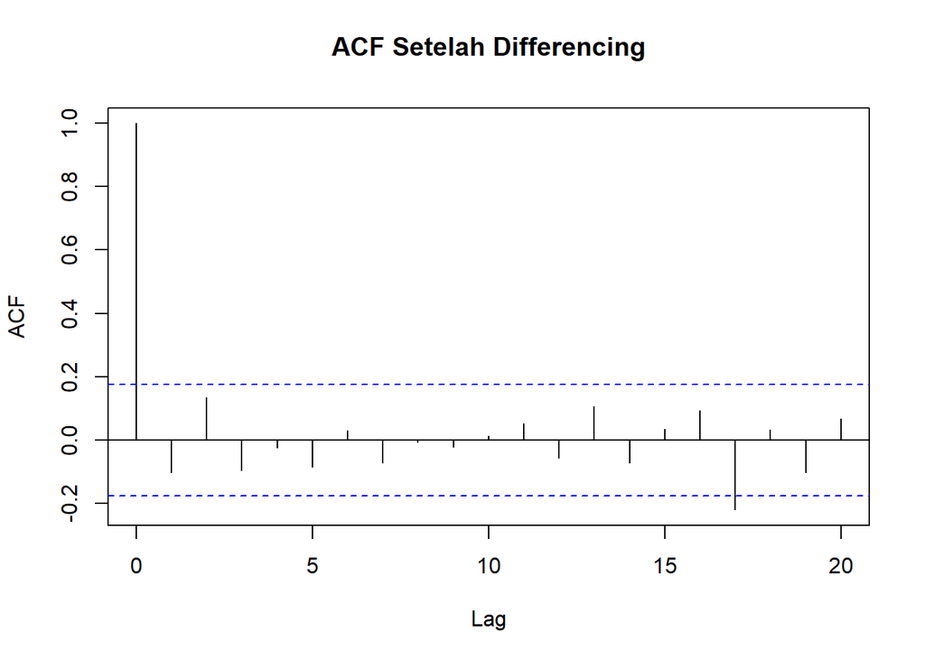

```r
acf(diff_data, main="ACF Setelah Differencing")
```

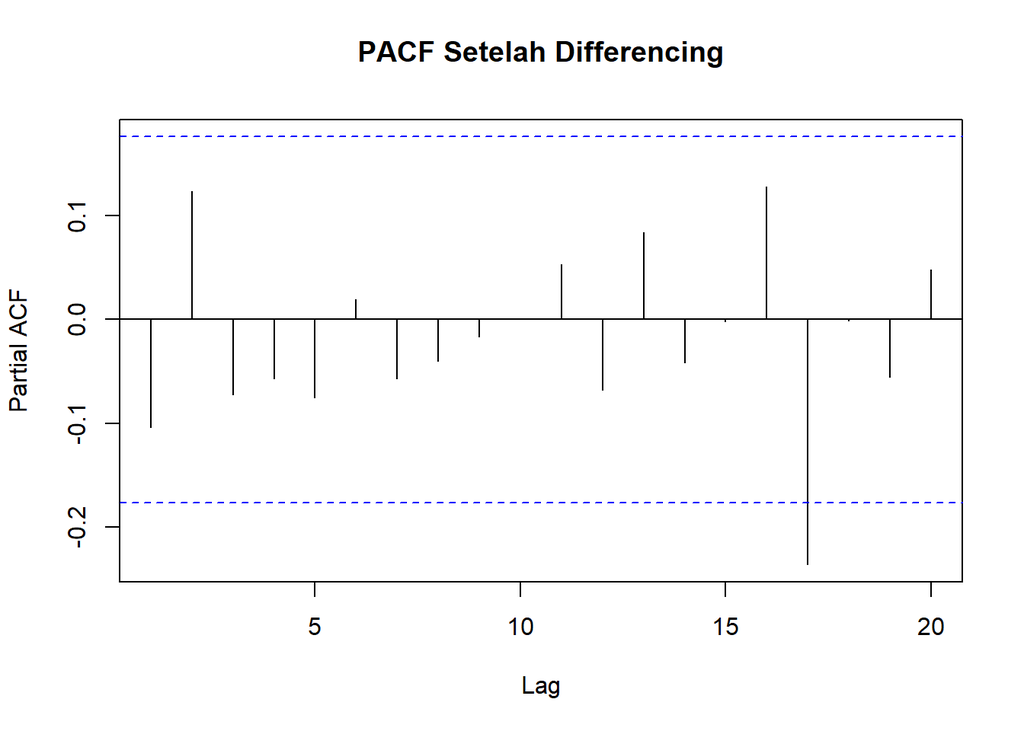

```r
pacf(diff_data, main="PACF Setelah Differencing")
```

```r
adf.test(diff_data)
```

```
##
##  Augmented Dickey-Fuller Test
##
## data:  diff_data
## Dickey-Fuller = -5.3809, Lag order = 4, p-value = 0.01
## alternative hypothesis: stationary
```

### Uji Stasioneritas Setelah Differencing

Setelah dilakukan differencing orde 1, hasil uji menunjukkan bahwa data sudah stasioner:

- ACF cepat turun menuju nol, tidak seperti pada data asli.
- PACF tidak menunjukkan pola yang kuat.
- Uji Augmented Dickey-Fuller memberikan nilai p-value = 0.01 (< 0.05), sehingga hipotesis nol (data tidak stasioner) ditolak.Hal ini berarti data telah **stasioner dalam rataan**.
- Plot setelah differencing juga memperlihatkan variabilitas yang relatif konstan, sehingga dapat disimpulkan bahwa data sudah **stasioner dalam rataan dan ragam**.

**Kesimpulan:** Data telah stasioner setelah dilakukan differencing orde 1, sehingga dapat digunakan untuk proses pemodelan lebih lanjut (misalnya ARIMA).

## Pendugaan Parameter Model

Karena data telah stasioner setelah differencing orde 1, maka parameter **d = 1**.  
Berdasarkan pola ACF dan PACF, dicoba beberapa kombinasi orde ARIMA yaitu (1,1,0), (0,1,1), dan (1,1,1).  
Pendugaan parameter dilakukan menggunakan metode **Maximum Likelihood (ML)**.

Nilai **AIC (Akaike Information Criterion)** dari masing-masing model digunakan untuk membandingkan mana yang paling baik.  
Model dengan **AIC terkecil** akan dipilih sebagai model terbaik untuk data ini.

```r
#---SETUP---
library(forecast)   # berisi fungsi Arima()
library(lmtest)     # buat coeftest()
# Membentuk data training
data.train <- data$nilai

# Model 1: ARIMA(0,1,1)
model1 <- Arima(data.train, order=c(0,1,1), method="ML")
summary(model1) # lihat nilai AIC
```

```
## Series: data.train
## ARIMA(0,1,1)
##
## Coefficients:
##           ma1
##       -0.0795
## s.e.   0.0807
##
## sigma^2 = 20468:  log likelihood = -790.89
## AIC=1585.79   AICc=1585.89   BIC=1591.43
##
## Training set error measures:
##                    ME     RMSE      MAE       MPE      MAPE    MASE        ACF1
## Training set 11.15133 141.9165 113.3633 0.0698122 0.7374187 0.99105 -0.01536303
```

```r
lmtest::coeftest(model1) # cek signifikansi parameter
```

```
##
## z test of coefficients:
##
##      Estimate Std. Error z value Pr(>|z|)
## ma1 -0.079468   0.080683 -0.9849   0.3247
```

```r
# Model 2: ARIMA(1,1,0)
model2 <- Arima(data.train, order=c(1,1,0), method="ML")
summary(model2) # lihat nilai AIC
```

```
## Series: data.train
## ARIMA(1,1,0)
##
## Coefficients:
##           ar1
##       -0.0992
## s.e.   0.0896
##
## sigma^2 = 20426:  log likelihood = -790.77
## AIC=1585.54   AICc=1585.64   BIC=1591.18
##
## Training set error measures:
##                    ME     RMSE      MAE        MPE      MAPE      MASE
## Training set 11.25398 141.7722 113.4485 0.07046832 0.7379597 0.9917946
##                     ACF1
## Training set 0.007255237
```

```r
lmtest::coeftest(model2) # cek signifikansi parameter
```

```
##
## z test of coefficients:
##
##      Estimate Std. Error z value Pr(>|z|)
## ar1 -0.099202   0.089614  -1.107   0.2683
```

```r
# Model 3: ARIMA(1,1,1)
model3 <- Arima(data.train, order=c(1,1,1), method="ML")
summary(model3) # lihat nilai AIC
```

```
## Series: data.train
## ARIMA(1,1,1)
##
## Coefficients:
##           ar1     ma1
##       -0.7693  0.6653
## s.e.   0.2324  0.2706
##
## sigma^2 = 20253:  log likelihood = -789.75
## AIC=1585.51   AICc=1585.71   BIC=1593.97
##
## Training set error measures:
##                    ME     RMSE      MAE        MPE      MAPE      MASE     ACF1
## Training set 10.90208 140.5934 111.7881 0.06832292 0.7271499 0.9772787 0.020948
```

```r
lmtest::coeftest(model3) # cek signifikansi parameter
```

```
##
## z test of coefficients:
##
##     Estimate Std. Error z value  Pr(>|z|)
## ar1 -0.76926    0.23243 -3.3096 0.0009342 ***
## ma1  0.66528    0.27065  2.4581 0.0139664 *
## ---
## Signif. codes:  0 '***' 0.001 '**' 0.01 '*' 0.05 '.' 0.1 ' ' 1
```

```r
# Model 4: ARIMA(2,1,2)
model4 <- Arima(data.train, order=c(2,1,2), method="ML")
summary(model4) # lihat nilai AIC
```

```
## Series: data.train
## ARIMA(2,1,2)
##
## Coefficients:
##           ar1     ar2     ma1     ma2
##       -0.4243  0.0008  0.3441  0.1055
## s.e.   0.7600  1.0190  0.7575  1.1184
##
## sigma^2 = 20518:  log likelihood = -789.54
## AIC=1589.08   AICc=1589.58   BIC=1603.18
##
## Training set error measures:
##                    ME     RMSE      MAE        MPE      MAPE      MASE
## Training set 10.12741 140.3474 111.5784 0.06347809 0.7259013 0.9754455
##                      ACF1
## Training set -0.004677596
```

```r
lmtest::coeftest(model4) # cek signifikansi parameter
```

```
##
## z test of coefficients:
##
##        Estimate  Std. Error z value Pr(>|z|)
## ar1 -0.42432939  0.75999054 -0.5583   0.5766
## ar2  0.00080129  1.01896361  0.0008   0.9994
## ma1  0.34408980  0.75753361  0.4542   0.6497
## ma2  0.10549992  1.11837240  0.0943   0.9248
```

```r
# Model 5: ARIMA(0,1,2)
model5 <- Arima(data.train, order=c(0,1,2), method="ML")
summary(model5)
```

```
## Series: data.train
## ARIMA(0,1,2)
##
## Coefficients:
##           ma1     ma2
##       -0.0699  0.1413
## s.e.   0.0894  0.0943
##
## sigma^2 = 20268:  log likelihood = -789.8
## AIC=1585.6   AICc=1585.8   BIC=1594.06
##
## Training set error measures:
##                    ME    RMSE      MAE        MPE      MAPE      MASE
## Training set 9.599788 140.646 112.3188 0.06015599 0.7308474 0.9819183
##                     ACF1
## Training set -0.01462038
```

```r
lmtest::coeftest(model5)
```

```
##
## z test of coefficients:
##
##      Estimate Std. Error z value Pr(>|z|)
## ma1 -0.069905   0.089371 -0.7822   0.4341
## ma2  0.141256   0.094252  1.4987   0.1340
```

```r
#---PERBANDINGAN NILAI AIC DAN BIC---

hasil_model <- data.frame(
  Model = c("ARIMA(0,1,1)",
            "ARIMA(1,1,0)",
            "ARIMA(1,1,1)",
            "ARIMA(2,1,2)",
            "ARIMA(0,1,2)"),

  AIC = c(
    AIC(model1),
    AIC(model2),
    AIC(model3),
    AIC(model4),
    AIC(model5)
  ),

  BIC = c(
    BIC(model1),
    BIC(model2),
    BIC(model3),
    BIC(model4),
    BIC(model5)
  )
)

hasil_model
```

```
##          Model      AIC      BIC
## 1 ARIMA(0,1,1) 1585.788 1591.429
## 2 ARIMA(1,1,0) 1585.539 1591.180
## 3 ARIMA(1,1,1) 1585.505 1593.966
## 4 ARIMA(2,1,2) 1589.076 1603.177
## 5 ARIMA(0,1,2) 1585.595 1594.056
```

Berdasarkan hasil pendugaan parameter di atas, diperoleh bahwa nilai **AIC terkecil dimiliki oleh model ARIMA(1,1,1)** dengan nilai AIC = 1585.505.  
Selain itu, hasil uji signifikansi parameter menunjukkan bahwa seluruh parameter pada model ARIMA(1,1,1) signifikan secara statistik.

Dengan demikian, **model terbaik yang dipilih adalah ARIMA(1,1,1)** karena memiliki nilai AIC paling kecil dan parameter yang signifikan.

## Analisis Sisaan

### Eksplorasi Sisaan

```r
#---EKSPLORASI SISAAN---

sisaan.arima111 <- model3$residuals
par(mfrow=c(2,2))

#qqnorm(sisaan.arima111)
#qqline(sisaan.arima111, col = "blue", lwd = 2)
car::qqPlot(sisaan.arima111)
```

```
## [1] 40 82
```

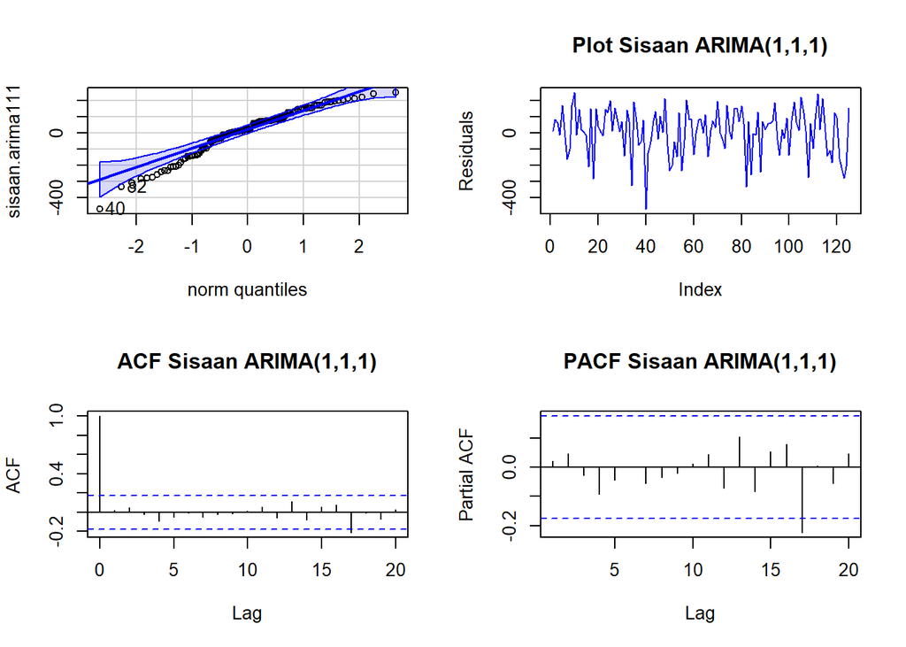

```r
plot(c(1:length(sisaan.arima111)), sisaan.arima111,
     main="Plot Sisaan ARIMA(1,1,1)",
     ylab="Residuals", xlab="Index", type="l", col="blue")

# ACF dan PACF sisaan
acf(sisaan.arima111, main="ACF Sisaan ARIMA(1,1,1)")
pacf(sisaan.arima111, main="PACF Sisaan ARIMA(1,1,1)")
```

Berdasarkan plot kuantil-kuantil normal, secara eksplorasi ditunjukkan bahwa sisaan model ARIMA(1,1,1) menyebar normal karena sebagian besar titik mengikuti garis diagonal pada QQ plot.  
Selain itu, plot sisaan memperlihatkan lebar pita fluktuasi yang relatif konstan, menandakan bahwa sisaan memiliki **ragam yang homogen**.

### Uji Formal

```r
#1) Sisaan Menyebar Normal
ks.test(sisaan.arima111, "pnorm")
```

```
##
##  Asymptotic one-sample Kolmogorov-Smirnov test
##
## data:  sisaan.arima111
## D = 0.60795, p-value < 2.2e-16
## alternative hypothesis: two-sided
```

H₀ : Sisaan menyebar normal  
H₁ : Sisaan tidak menyebar normal

Berdasarkan hasil uji **Kolmogorov–Smirnov (KS)** terhadap sisaan model ARIMA(1,1,1), diperoleh p-value < 2.2e-16 yang lebih kecil dari taraf nyata 5% (0.05), sehingga secara formal **H₀ ditolak** dan sisaan **tidak menyebar normal**.

Namun, berdasarkan hasil eksplorasi menggunakan plot kuantil-kuantil normal (QQ plot), sebaran titik residual tampak mengikuti garis diagonal, yang menunjukkan bahwa **secara visual sisaan cenderung mendekati sebaran normal**.

Perbedaan ini dapat disebabkan oleh sensitivitas uji KS terhadap ukuran sampel yang besar, sehingga kesimpulan praktis tetap dapat menyatakan bahwa **sisaan berdistribusi hampir normal dan dapat diterima untuk analisis lebih lanjut.**

```r
#2) Sisaan saling bebas/tidak ada autokorelasi
Box.test(sisaan.arima111, type = "Ljung")
```

```
##
##  Box-Ljung test
##
## data:  sisaan.arima111
## X-squared = 0.056179, df = 1, p-value = 0.8126
```

H₀ : Sisaan saling bebas (tidak ada autokorelasi)  
H₁ : Sisaan tidak saling bebas (terdapat autokorelasi)

Berdasarkan hasil uji Ljung-Box, diperoleh **p-value = 0.8126**, yang lebih besar dari taraf nyata 5% (0.05).  
Dengan demikian, **gagal menolak H₀**, artinya **sisaan saling bebas atau tidak terdapat autokorelasi antar residual**.

```r
#3) Sisaan homogen
Box.test((sisaan.arima111)^2, type = "Ljung")
```

```
##
##  Box-Ljung test
##
## data:  (sisaan.arima111)^2
## X-squared = 0.80852, df = 1, p-value = 0.3686
```

Uji ini dilakukan untuk memeriksa apakah **ragam sisaan homogen (konstan)** menggunakan **uji Ljung-Box terhadap sisaan kuadrat**.  
Hipotesis yang digunakan adalah:

H₀ : Ragam sisaan homogen  
H₁ : Ragam sisaan tidak homogen

Berdasarkan hasil uji Ljung-Box terhadap sisaan kuadrat, diperoleh **p-value = 0.3686**, yang lebih besar dari taraf nyata 5% (0.05).  
Dengan demikian, **gagal menolak H₀**, artinya **ragam sisaan homogen atau konstan**.

Hasil ini mendukung temuan dari eksplorasi visual, di mana fluktuasi sisaan tampak memiliki lebar pita yang relatif sama sepanjang waktu.

```r
#4) Nilai tengah sisaan sama dengan nol
t.test(sisaan.arima111, mu = 0, conf.level = 0.95)
```

```
##
##  One Sample t-test
##
## data:  sisaan.arima111
## t = 0.86609, df = 124, p-value = 0.3881
## alternative hypothesis: true mean is not equal to 0
## 95 percent confidence interval:
##  -14.01240  35.81657
## sample estimates:
## mean of x
##  10.90208
```

Uji ini dilakukan untuk memastikan apakah **rataan (mean) sisaan sama dengan nol** menggunakan **uji t satu sampel**.  
Hipotesis yang diuji adalah sebagai berikut:

H₀ : Nilai tengah sisaan sama dengan 0  
H₁ : Nilai tengah sisaan tidak sama dengan 0

Berdasarkan hasil uji t, diperoleh **p-value = 0.3881**, yang lebih besar dari taraf nyata 5% (0.05).  
Dengan demikian, **gagal menolak H₀**, artinya **nilai tengah sisaan tidak berbeda secara signifikan dari nol**.

Hasil ini menunjukkan bahwa sisaan model **ARIMA(1,1,1)** memiliki rata-rata mendekati nol, sesuai dengan asumsi dasar model deret waktu yang baik.

## Overfitting

Tahapan selanjutnya adalah **uji overfitting**, yang dilakukan dengan menaikkan orde AR(p) dan MA(q) dari model-model kandidat sebelumnya untuk melihat apakah terdapat model lain yang lebih baik.  
Kandidat model overfitting yang diuji antara lain: - ARIMA(2,1,1) - ARIMA(1,1,2) - ARIMA(2,1,2)

Setiap model dibandingkan berdasarkan nilai **AIC** dan **BIC**, serta signifikansi parameternya.  
Model dengan AIC dan BIC paling kecil serta seluruh parameter signifikan akan dipilih sebagai model terbaik.

```r
#---OVERFITTING---

# Overfitting dilakukan dengan menaikkan orde AR(p) dan MA(q)
# dari model terbaik yang telah diperoleh.

# Kandidat overfitting:
# 1) Naikkan orde AR dari ARIMA(1,1,1) → ARIMA(2,1,1)
model1a.arima <- Arima(data.train, order=c(2,1,1), method="ML")
summary(model1a.arima)
```

```
## Series: data.train
## ARIMA(2,1,1)
##
## Coefficients:
##           ar1     ar2     ma1
##       -0.4330  0.0969  0.3536
## s.e.   0.6647  0.1345  0.6699
##
## sigma^2 = 20349:  log likelihood = -789.54
## AIC=1587.08   AICc=1587.42   BIC=1598.36
##
## Training set error measures:
##                   ME     RMSE     MAE        MPE      MAPE      MASE
## Training set 10.1688 140.3506 111.315 0.06373542 0.7241725 0.9731428
##                     ACF1
## Training set -0.00445106
```

```r
lmtest::coeftest(model1a.arima)
```

```
##
## z test of coefficients:
##
##     Estimate Std. Error z value Pr(>|z|)
## ar1 -0.43305    0.66469 -0.6515   0.5147
## ar2  0.09695    0.13450  0.7208   0.4710
## ma1  0.35363    0.66989  0.5279   0.5976
```

```r
# 2) Naikkan orde MA dari ARIMA(1,1,1) → ARIMA(1,1,2)
model1b.arima <- Arima(data.train, order=c(1,1,2), method="ML")
summary(model1b.arima)
```

```
## Series: data.train
## ARIMA(1,1,2)
##
## Coefficients:
##           ar1     ma1     ma2
##       -0.4298  0.3494  0.1054
## s.e.   0.7466  0.7423  0.1510
##
## sigma^2 = 20349:  log likelihood = -789.54
## AIC=1587.08   AICc=1587.41   BIC=1598.36
##
## Training set error measures:
##                    ME     RMSE      MAE        MPE      MAPE      MASE
## Training set 10.13512 140.3473 111.5705 0.06352639 0.7258486 0.9753764
##                      ACF1
## Training set -0.004542918
```

```r
lmtest::coeftest(model1b.arima)
```

```
##
## z test of coefficients:
##
##     Estimate Std. Error z value Pr(>|z|)
## ar1 -0.42979    0.74663 -0.5756   0.5649
## ma1  0.34941    0.74233  0.4707   0.6379
## ma2  0.10545    0.15096  0.6985   0.4849
```

```r
# 3) Naikkan keduanya dari ARIMA(1,1,1) → ARIMA(2,1,2)
model1c.arima <- Arima(data.train, order=c(2,1,2), method="ML")
summary(model1c.arima)
```

```
## Series: data.train
## ARIMA(2,1,2)
##
## Coefficients:
##           ar1     ar2     ma1     ma2
##       -0.4243  0.0008  0.3441  0.1055
## s.e.   0.7600  1.0190  0.7575  1.1184
##
## sigma^2 = 20518:  log likelihood = -789.54
## AIC=1589.08   AICc=1589.58   BIC=1603.18
##
## Training set error measures:
##                    ME     RMSE      MAE        MPE      MAPE      MASE
## Training set 10.12741 140.3474 111.5784 0.06347809 0.7259013 0.9754455
##                      ACF1
## Training set -0.004677596
```

```r
lmtest::coeftest(model1c.arima)
```

```
##
## z test of coefficients:
##
##        Estimate  Std. Error z value Pr(>|z|)
## ar1 -0.42432939  0.75999054 -0.5583   0.5766
## ar2  0.00080129  1.01896361  0.0008   0.9994
## ma1  0.34408980  0.75753361  0.4542   0.6497
## ma2  0.10549992  1.11837240  0.0943   0.9248
```

```r
# Membandingkan nilai AIC dan BIC antar model
overfitting <- data.frame(
  Model = c("ARIMA(1,1,1)",
            "ARIMA(2,1,1)",
            "ARIMA(1,1,2)",
            "ARIMA(2,1,2)"),
  AIC = c(
    AIC(model3),
    AIC(model1a.arima),
    AIC(model1b.arima),
    AIC(model1c.arima)
  ),
  BIC = c(
    BIC(model3),
    BIC(model1a.arima),
    BIC(model1b.arima),
    BIC(model1c.arima)
  )
)

overfitting
```

```
##          Model      AIC      BIC
## 1 ARIMA(1,1,1) 1585.505 1593.966
## 2 ARIMA(2,1,1) 1587.082 1598.364
## 3 ARIMA(1,1,2) 1587.076 1598.357
## 4 ARIMA(2,1,2) 1589.076 1603.177
```

Berdasarkan hasil overfitting di atas, model ARIMA(1,1,1) memiliki nilai AIC dan BIC terkecil dibandingkan dengan model-model kandidat lainnya (ARIMA(2,1,1), ARIMA(1,1,2), dan ARIMA(2,1,2)). Nilai AIC = 1585.505 dan BIC = 1593.966 menunjukkan bahwa model ini paling efisien dalam menjelaskan variasi data dengan kompleksitas parameter yang relatif sederhana.

Model terbaik yang dipilih setelah proses overfitting adalah ARIMA(1,1,1) karena memiliki nilai AIC dan BIC terkecil, sehingga model ini digunakan untuk tahap peramalan selanjutnya.

## Peramalan

```r
#---MODEL TERBAIK---
model3.arima111 <- forecast::Arima(data.train, order = c(1,1,1), method = "ML")
summary(model3.arima111)
```

```
## Series: data.train
## ARIMA(1,1,1)
##
## Coefficients:
##           ar1     ma1
##       -0.7693  0.6653
## s.e.   0.2324  0.2706
##
## sigma^2 = 20253:  log likelihood = -789.75
## AIC=1585.51   AICc=1585.71   BIC=1593.97
##
## Training set error measures:
##                    ME     RMSE      MAE        MPE      MAPE      MASE     ACF1
## Training set 10.90208 140.5934 111.7881 0.06832292 0.7271499 0.9772787 0.020948
```

```r
#---FORECAST---
ramalan <- forecast::forecast(model3.arima111, h = 30)
ramalan
```

```
##     Point Forecast    Lo 80    Hi 80    Lo 95    Hi 95
## 126       15626.82 15444.44 15809.20 15347.89 15905.75
## 127       15643.88 15399.00 15888.76 15269.37 16018.40
## 128       15630.76 15328.01 15933.50 15167.75 16093.76
## 129       15640.85 15295.21 15986.50 15112.24 16169.47
## 130       15633.09 15245.48 16020.69 15040.29 16225.88
## 131       15639.06 15216.30 16061.82 14992.51 16285.61
## 132       15634.47 15177.34 16091.59 14935.36 16333.57
## 133       15638.00 15150.31 16125.69 14892.14 16383.86
## 134       15635.28 15117.82 16152.74 14843.90 16426.67
## 135       15637.37 15092.50 16182.25 14804.06 16470.68
## 136       15635.76 15064.26 16207.27 14761.72 16509.81
## 137       15637.00 15040.44 16233.56 14724.64 16549.36
## 138       15636.05 15015.16 16256.94 14686.47 16585.63
## 139       15636.78 14992.69 16280.88 14651.73 16621.84
```

[output cut: 16 more lines]

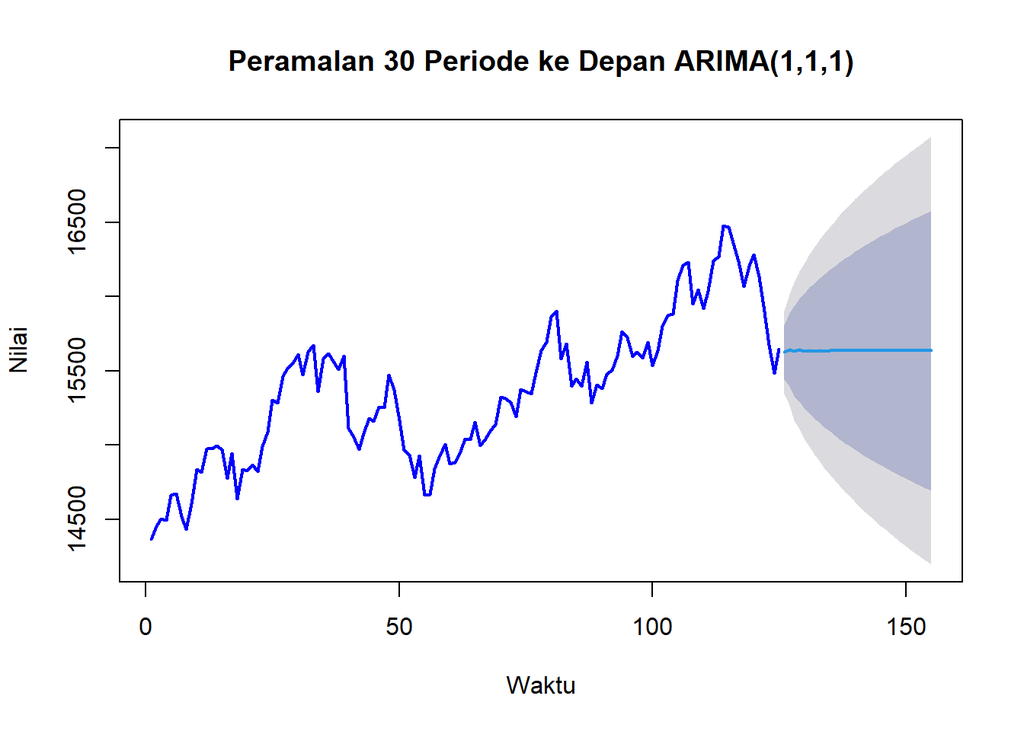

```r
#---VISUALISASI HASIL PERAMALAN---
data.ramalan <- ramalan$mean
plot(ramalan,
     main = "Peramalan 30 Periode ke Depan ARIMA(1,1,1)",
     xlab = "Waktu",
     ylab = "Nilai",
     col = "blue",
     lwd = 2)
```

```r
#---MODEL TERBAIK (NON-ZERO MEAN)---
model3.arima111 <- forecast::Arima(data.train, order = c(1,1,1), method = "ML", include.mean = TRUE)
summary(model3.arima111)
```

```
## Series: data.train
## ARIMA(1,1,1)
##
## Coefficients:
##           ar1     ma1
##       -0.7693  0.6653
## s.e.   0.2324  0.2706
##
## sigma^2 = 20253:  log likelihood = -789.75
## AIC=1585.51   AICc=1585.71   BIC=1593.97
##
## Training set error measures:
##                    ME     RMSE      MAE        MPE      MAPE      MASE     ACF1
## Training set 10.90208 140.5934 111.7881 0.06832292 0.7271499 0.9772787 0.020948
```

```r
#---FORECAST---
ramalan <- forecast::forecast(model3.arima111, h = 30)
ramalan
```

```
##     Point Forecast    Lo 80    Hi 80    Lo 95    Hi 95
## 126       15626.82 15444.44 15809.20 15347.89 15905.75
## 127       15643.88 15399.00 15888.76 15269.37 16018.40
## 128       15630.76 15328.01 15933.50 15167.75 16093.76
## 129       15640.85 15295.21 15986.50 15112.24 16169.47
## 130       15633.09 15245.48 16020.69 15040.29 16225.88
## 131       15639.06 15216.30 16061.82 14992.51 16285.61
## 132       15634.47 15177.34 16091.59 14935.36 16333.57
## 133       15638.00 15150.31 16125.69 14892.14 16383.86
## 134       15635.28 15117.82 16152.74 14843.90 16426.67
## 135       15637.37 15092.50 16182.25 14804.06 16470.68
## 136       15635.76 15064.26 16207.27 14761.72 16509.81
## 137       15637.00 15040.44 16233.56 14724.64 16549.36
## 138       15636.05 15015.16 16256.94 14686.47 16585.63
## 139       15636.78 14992.69 16280.88 14651.73 16621.84
```

[output cut: 16 more lines]

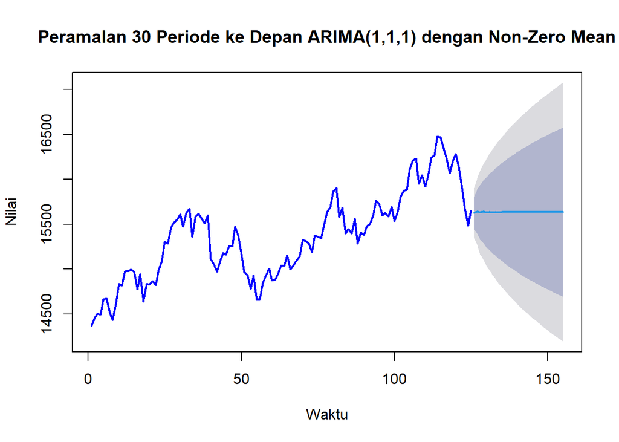

```r
#---VISUALISASI HASIL PERAMALAN---
data.ramalan <- ramalan$mean
plot(ramalan,
     main = "Peramalan 30 Periode ke Depan ARIMA(1,1,1) dengan Non-Zero Mean",
     xlab = "Waktu",
     ylab = "Nilai",
     col = "blue",
     lwd = 2)
```

```r
#---PERBANDINGAN AKTUAL VS HASIL FORECAST---

# misalnya data.test adalah 30 nilai aktual terakhir (buat pembanding)
data.test <- tail(data$nilai, 30)

# ambil hasil forecast (mean)
data.ramalan <- ramalan$mean

# buat matriks perbandingan aktual vs forecast
perbandingan <- matrix(
  data = c(data.test, data.ramalan),
  nrow = length(data.ramalan),
  ncol = 2
)

# beri nama kolom dan ubah ke data frame
colnames(perbandingan) <- c("Aktual", "Hasil Forecast")
perbandingan <- as.data.frame(perbandingan)

# tampilkan 10 baris pertama
head(perbandingan, 10)
```

```
##    Aktual Hasil Forecast
## 1   15598       15626.82
## 2   15629       15643.88
## 3   15586       15630.76
## 4   15692       15640.85
## 5   15536       15633.09
## 6   15639       15639.06
## 7   15803       15634.47
## 8   15873       15638.00
## 9   15883       15635.28
## 10  16112       15637.37
```

```r
#---AKURASI---
akurasi <- forecast::accuracy(data.ramalan, data.test)
akurasi
```

```
##                ME     RMSE      MAE      MPE     MAPE
## Test set 337.9182 443.7678 360.4557 2.083577 2.228714
```

## Kesimpulan Akhir

Berdasarkan hasil pengujian akurasi, diperoleh nilai-nilai sebagai berikut: ME = 337.9182 RMSE = 443.7678 MAE = 360.4557 MPE = 2.083577 MAPE = 2.228714